# Binary Classification Model for Truck APS Failure Detection Using R Take 2

David Lowe

November 7, 2018

Template Credit: Adapted from a template made available by Dr. Jason Brownlee of Machine Learning Mastery. https://machinelearningmastery.com/

SUMMARY: The purpose of this project is to construct a prediction model using various machine learning algorithms and to document the end-to-end steps using a template. The APS Failure at Scania Trucks dataset is a binary-class classification situation where we are trying to predict one of the two possible outcomes.

INTRODUCTION: The dataset consists of data collected from heavy Scania trucks in everyday usage. The system in focus is the Air Pressure system (APS) which generates pressurized air that is utilized in various functions in a truck, such as braking and gear changes. The dataset’s positive class consists of component failures for a specific component of the APS system. The negative class consists of trucks with failures for components not related to the APS. The data consists of a subset of all available data, selected by experts.

This dataset has many cells with missing values, so it is not practical to simply delete the rows with missing cells. This iteration of the project will impute the blank cells with the value zero.

In iteration Take1, the script focused on evaluating various machine learning algorithms and identifying the algorithm that produces the best accuracy result. Iteration Take1 established a baseline performance regarding accuracy and processing time.

For this iteration, we will examine the feasibility of using a dimensionality reduction technique to reduce the processing time while still maintaining an adequate level of prediction accuracy. The technique is to eliminate collinear attributes based on a threshold of 75%.

ANALYSIS: From the previous iteration Take1, the baseline performance of the ten algorithms achieved an average accuracy of 99.02%. Three ensemble algorithms (Bagged CART, Random Forest, and Stochastic Gradient Boosting) achieved the top accuracy scores after the first round of modeling. After a series of tuning trials, Random Forest turned in the top result using the training data. It achieved an average accuracy of 99.39%. Using the optimized tuning parameter available, the Random Forest algorithm processed the validation dataset with an accuracy of 99.22%, which was slightly below the accuracy of the training data.

CONCLUSION: The feature selection technique helped by cutting down the attribites and reduced the training time. Furthermore, the modeling took a much shorter time to process yet still retained an almost-identical level of accuracy. For this dataset, the Random Forest algorithm and the technique of eliminating collinear attributes should be considered for further modeling or production use.

Dataset Used: APS Failure at Scania Trucks Data Set

Dataset ML Model: Binary classification with numerical attributes

Dataset Reference: https://archive.ics.uci.edu/ml/datasets/APS+Failure+at+Scania+Trucks

One potential source of performance benchmark: https://www.kaggle.com/uciml/aps-failure-at-scania-trucks-data-set/home

The project aims to touch on the following areas:

1. Document a predictive modeling problem end-to-end.
2. Explore data cleaning and transformation options
3. Explore non-ensemble and ensemble algorithms for baseline model performance
4. Explore algorithm tuning techniques for improving model performance

Any predictive modeling machine learning project genrally can be broken down into about six major tasks:

1. Prepare Problem
2. Summarize Data
3. Prepare Data
4. Model and Evaluate Algorithms
5. Improve Accuracy or Results
6. Finalize Model and Present Results

## 1. Prepare Problem

### 1.a) Load libraries

```r
startTimeScript <- proc.time()
library(caret)
```

```r
library(corrplot)
library(ROCR)
library(parallel)

# Create one random seed number for reproducible results
seedNum <- 888
set.seed(seedNum)
```

### 1.b) Load dataset

```r
xy_train <- read.csv("aps_failure_training_set.csv", header= TRUE, na.strings="na", stringsAsFactors = T)
xy_test <- read.csv("aps_failure_test_set.csv", header= TRUE, na.strings="na", stringsAsFactors = T)
```

```r
# Use variable totCol to hold the number of columns in the dataframe
totCol <- ncol(xy_train)

# Set up variable totAttr for the total number of attribute columns
totAttr <- totCol-1
```

```r
# targetCol variable indicates the column location of the target/class variable
# If the first column, set targetCol to 1. If the last column, set targetCol to totCol
# if (targetCol <> 1) and (targetCol <> totCol), be aware when slicing up the dataframes for visualization!
targetCol <- 1
colnames(xy_train)[targetCol] <- "targetVar"
colnames(xy_test)[targetCol] <- "targetVar"
```

```r
# We create training datasets (xy_train, x_train, y_train) for various operations.
# We create validation datasets (xy_test, x_test, y_test) for various operations.
set.seed(seedNum)

# Create a list of the rows in the original dataset we can use for training
# training_index <- createDataPartition(originalDataset$targetVar, p=0.70, list=FALSE)
# Use 70% of the data to train the models and the remaining test/validation
# xy_train <- originalDataset[training_index,]
# xy_test <- originalDataset[-training_index,]

if (targetCol==1) {
x_train <- xy_train[,(targetCol+1):totCol]
y_train <- xy_train[,targetCol]
y_test <- xy_test[,targetCol]
} else {
x_train <- xy_train[,1:(totAttr)]
y_train <- xy_train[,totCol]
y_test <- xy_test[,totCol]
}
```

### 1.c) Set up the key parameters to be used in the script

```r
# Set up the number of row and columns for visualization display. dispRow * dispCol should be >= totAttr
dispCol <- 5
if (totAttr%%dispCol == 0) {
dispRow <- totAttr%/%dispCol
} else {
dispRow <- (totAttr%/%dispCol) + 1
}
cat("Will attempt to create graphics grid (col x row): ", dispCol, ' by ', dispRow)
```

```
## Will attempt to create graphics grid (col x row):  5  by  34
```

```r
# Run algorithms using 10-fold cross validation
control <- trainControl(method="repeatedcv", number=10, repeats=1)
metricTarget <- "Accuracy"
```

## 2. Summarize Data

To gain a better understanding of the data that we have on-hand, we will leverage a number of descriptive statistics and data visualization techniques. The plan is to use the results to consider new questions, review assumptions, and validate hypotheses that we can investigate later with specialized models.

### 2.a) Descriptive statistics

#### 2.a.i) Peek at the data itself.

```r
head(xy_train)
```

```
##   targetVar aa_000 ab_000     ac_000 ad_000 ae_000 af_000 ag_000 ag_001
## 1       neg  76698     NA 2130706438    280      0      0      0      0
## 2       neg  33058     NA          0     NA      0      0      0      0
## 3       neg  41040     NA        228    100      0      0      0      0
## 4       neg     12      0         70     66      0     10      0      0
## 5       neg  60874     NA       1368    458      0      0      0      0
## 6       neg  38312     NA 2130706432    218      0      0      0      0
##   ag_002 ag_003 ag_004  ag_005  ag_006  ag_007 ag_008 ag_009  ah_000
## 1      0      0  37250 1432864 3664156 1007684  25896      0 2551696
## 2      0      0  18254  653294 1720800  516724  31642      0 1393352
## 3      0      0   1648  370592 1883374  292936  12016      0 1234132
## 4      0    318   2212    3232    1872       0      0      0    2668
## 5      0      0  43752 1966618 1800340  131646   4588      0 1974038
## 6      0      0   9128  701702 1462836  449716  39000    660 1087760
##   ai_000 aj_000 ak_000 al_000 am_0  an_000  ao_000  ap_000  aq_000 ar_000
```

[output cut: 111 more lines]

#### 2.a.ii) Dimensions of the dataset.

```r
dim(xy_train)
```

```
## [1] 60000   171
```

```r
dim(xy_test)
```

```
## [1] 16000   171
```

#### 2.a.iii) Types of the attributes.

```r
sapply(xy_train, class)
```

```
## targetVar    aa_000    ab_000    ac_000    ad_000    ae_000    af_000
##  "factor" "integer" "integer" "integer" "numeric" "integer" "integer"
##    ag_000    ag_001    ag_002    ag_003    ag_004    ag_005    ag_006
## "integer" "integer" "integer" "integer" "integer" "integer" "integer"
##    ag_007    ag_008    ag_009    ah_000    ai_000    aj_000    ak_000
## "integer" "integer" "integer" "integer" "integer" "integer" "integer"
##    al_000      am_0    an_000    ao_000    ap_000    aq_000    ar_000
## "integer" "integer" "integer" "integer" "integer" "integer" "integer"
##    as_000    at_000    au_000    av_000    ax_000    ay_000    ay_001
## "integer" "integer" "integer" "integer" "integer" "integer" "integer"
##    ay_002    ay_003    ay_004    ay_005    ay_006    ay_007    ay_008
## "integer" "integer" "integer" "integer" "integer" "integer" "integer"
##    ay_009    az_000    az_001    az_002    az_003    az_004    az_005
## "integer" "integer" "integer" "integer" "integer" "integer" "integer"
##    az_006    az_007    az_008    az_009    ba_000    ba_001    ba_002
## "integer" "integer" "integer" "integer" "integer" "integer" "integer"
##    ba_003    ba_004    ba_005    ba_006    ba_007    ba_008    ba_009
## "integer" "integer" "integer" "integer" "integer" "integer" "integer"
##    bb_000    bc_000    bd_000    be_000    bf_000    bg_000    bh_000
## "integer" "integer" "integer" "integer" "integer" "integer" "integer"
##    bi_000    bj_000    bk_000    bl_000    bm_000    bn_000    bo_000
## "integer" "integer" "integer" "integer" "integer" "integer" "integer"
##    bp_000    bq_000    br_000    bs_000    bt_000    bu_000    bv_000
## "integer" "integer" "integer" "integer" "numeric" "integer" "integer"
##    bx_000    by_000    bz_000    ca_000    cb_000    cc_000    cd_000
## "integer" "numeric" "integer" "integer" "integer" "integer" "integer"
##    ce_000    cf_000    cg_000    ch_000    ci_000    cj_000    ck_000
## "integer" "numeric" "integer" "integer" "numeric" "numeric" "numeric"
##    cl_000    cm_000    cn_000    cn_001    cn_002    cn_003    cn_004
## "integer" "integer" "integer" "integer" "integer" "integer" "integer"
##    cn_005    cn_006    cn_007    cn_008    cn_009    co_000    cp_000
## "integer" "integer" "integer" "integer" "integer" "numeric" "integer"
##    cq_000    cr_000    cs_000    cs_001    cs_002    cs_003    cs_004
## "integer" "integer" "integer" "integer" "integer" "integer" "integer"
##    cs_005    cs_006    cs_007    cs_008    cs_009    ct_000    cu_000
## "integer" "integer" "integer" "integer" "integer" "integer" "integer"
##    cv_000    cx_000    cy_000    cz_000    da_000    db_000    dc_000
## "integer" "integer" "integer" "integer" "integer" "integer" "integer"
##    dd_000    de_000    df_000    dg_000    dh_000    di_000    dj_000
## "integer" "integer" "integer" "integer" "integer" "integer" "integer"
##    dk_000    dl_000    dm_000    dn_000    do_000    dp_000    dq_000
## "integer" "integer" "integer" "integer" "integer" "integer" "numeric"
##    dr_000    ds_000    dt_000    du_000    dv_000    dx_000    dy_000
## "integer" "integer" "integer" "integer" "integer" "integer" "integer"
##    dz_000    ea_000    eb_000     ec_00    ed_000    ee_000    ee_001
## "integer" "integer" "integer" "numeric" "integer" "integer" "integer"
##    ee_002    ee_003    ee_004    ee_005    ee_006    ee_007    ee_008
## "integer" "integer" "integer" "integer" "integer" "integer" "integer"
##    ee_009    ef_000    eg_000
## "integer" "integer" "integer"
```

#### 2.a.iv) Statistical summary of all attributes.

```r
summary(xy_train)
```

```
##  targetVar       aa_000            ab_000           ac_000
##  neg:59000   Min.   :      0   Min.   :  0.00   Min.   :0.000e+00
##  pos: 1000   1st Qu.:    834   1st Qu.:  0.00   1st Qu.:1.600e+01
##              Median :  30776   Median :  0.00   Median :1.520e+02
##              Mean   :  59337   Mean   :  0.71   Mean   :3.560e+08
##              3rd Qu.:  48668   3rd Qu.:  0.00   3rd Qu.:9.640e+02
##              Max.   :2746564   Max.   :204.00   Max.   :2.131e+09
##                                NA's   :46329    NA's   :3335
##      ad_000              ae_000              af_000
##  Min.   :0.000e+00   Min.   :    0.000   Min.   :    0.00
##  1st Qu.:2.400e+01   1st Qu.:    0.000   1st Qu.:    0.00
##  Median :1.260e+02   Median :    0.000   Median :    0.00
##  Mean   :1.906e+05   Mean   :    6.819   Mean   :   11.01
##  3rd Qu.:4.300e+02   3rd Qu.:    0.000   3rd Qu.:    0.00
##  Max.   :8.584e+09   Max.   :21050.000   Max.   :20070.00
##  NA's   :14861       NA's   :2500        NA's   :2500
##      ag_000            ag_001            ag_002             ag_003
##  Min.   :      0   Min.   :      0   Min.   :       0   Min.   :       0
##  1st Qu.:      0   1st Qu.:      0   1st Qu.:       0   1st Qu.:       0
##  Median :      0   Median :      0   Median :       0   Median :       0
##  Mean   :    222   Mean   :    976   Mean   :    8606   Mean   :   88591
##  3rd Qu.:      0   3rd Qu.:      0   3rd Qu.:       0   3rd Qu.:       0
##  Max.   :3376892   Max.   :4109372   Max.   :10552856   Max.   :63402074
##  NA's   :671       NA's   :671       NA's   :671        NA's   :671
##      ag_004              ag_005              ag_006
##  Min.   :        0   Min.   :        0   Min.   :       0
##  1st Qu.:      308   1st Qu.:    13834   1st Qu.:   10608
##  Median :     3672   Median :   176020   Median :  930336
##  Mean   :   437097   Mean   :  1108374   Mean   : 1657818
##  3rd Qu.:    49522   3rd Qu.:   913964   3rd Qu.: 1886608
##  Max.   :228830570   Max.   :179187978   Max.   :94020666
##  NA's   :671         NA's   :671         NA's   :671
##      ag_007             ag_008             ag_009
##  Min.   :       0   Min.   :       0   Min.   :       0
##  1st Qu.:       0   1st Qu.:       0   1st Qu.:       0
##  Median :  119204   Median :    1786   Median :       0
##  Mean   :  499310   Mean   :   35570   Mean   :    5115
##  3rd Qu.:  588820   3rd Qu.:   26690   3rd Qu.:     364
##  Max.   :63346754   Max.   :17702522   Max.   :25198514
##  NA's   :671        NA's   :671        NA's   :671
```

[output cut: 369 more lines]

```
##  Min.   :       0   Min.   :      0   Min.   :  0.0000
##  1st Qu.:       0   1st Qu.:      0   1st Qu.:  0.0000
##  Median :    3812   Median :      0   Median :  0.0000
##  Mean   :  138730   Mean   :   8389   Mean   :  0.0906
##  3rd Qu.:  139724   3rd Qu.:   2028   3rd Qu.:  0.0000
##  Max.   :19267396   Max.   :3810078   Max.   :482.0000
##  NA's   :671        NA's   :671       NA's   :2724
##      eg_000
##  Min.   :   0.0000
##  1st Qu.:   0.0000
##  Median :   0.0000
##  Mean   :   0.2128
##  3rd Qu.:   0.0000
##  Max.   :1146.0000
##  NA's   :2723
```

#### 2.a.v) Summarize the levels of the class attribute.

```r
cbind(freq=table(y_train), percentage=prop.table(table(y_train))*100)
```

```
##      freq percentage
## neg 59000  98.333333
## pos  1000   1.666667
```

#### 2.a.vi) Count missing values.

```r
sapply(xy_train, function(x) sum(is.na(x)))
```

```
## targetVar    aa_000    ab_000    ac_000    ad_000    ae_000    af_000
##         0         0     46329      3335     14861      2500      2500
##    ag_000    ag_001    ag_002    ag_003    ag_004    ag_005    ag_006
##       671       671       671       671       671       671       671
##    ag_007    ag_008    ag_009    ah_000    ai_000    aj_000    ak_000
##       671       671       671       645       629       629      4400
##    al_000      am_0    an_000    ao_000    ap_000    aq_000    ar_000
##       642       629       642       589       642       589      2723
##    as_000    at_000    au_000    av_000    ax_000    ay_000    ay_001
##       629       629       629      2500      2501       671       671
##    ay_002    ay_003    ay_004    ay_005    ay_006    ay_007    ay_008
##       671       671       671       671       671       671       671
##    ay_009    az_000    az_001    az_002    az_003    az_004    az_005
##       671       671       671       671       671       671       671
##    az_006    az_007    az_008    az_009    ba_000    ba_001    ba_002
##       671       671       671       671       688       688       688
##    ba_003    ba_004    ba_005    ba_006    ba_007    ba_008    ba_009
##       688       688       688       688       688       688       688
##    bb_000    bc_000    bd_000    be_000    bf_000    bg_000    bh_000
##       645      2725      2727      2503      2500       642       642
##    bi_000    bj_000    bk_000    bl_000    bm_000    bn_000    bo_000
##       589       589     23034     27277     39549     44009     46333
##    bp_000    bq_000    br_000    bs_000    bt_000    bu_000    bv_000
##     47740     48722     49264       726       167       691       691
##    bx_000    by_000    bz_000    ca_000    cb_000    cc_000    cd_000
##      3257       473      2723      4356       726      3255       676
##    ce_000    cf_000    cg_000    ch_000    ci_000    cj_000    ck_000
##      2502     14861     14861     14861       338       338       338
##    cl_000    cm_000    cn_000    cn_001    cn_002    cn_003    cn_004
##      9553      9877       687       687       687       687       687
##    cn_005    cn_006    cn_007    cn_008    cn_009    co_000    cp_000
##       687       687       687       687       687     14861      2724
##    cq_000    cr_000    cs_000    cs_001    cs_002    cs_003    cs_004
##       691     46329       669       669       669       669       669
##    cs_005    cs_006    cs_007    cs_008    cs_009    ct_000    cu_000
##       669       669       669       669       669     13808     13808
##    cv_000    cx_000    cy_000    cz_000    da_000    db_000    dc_000
##     13808     13808     13808     13808     13808     13808     13808
##    dd_000    de_000    df_000    dg_000    dh_000    di_000    dj_000
##      2503      2724      4008      4008      4008      4006      4007
##    dk_000    dl_000    dm_000    dn_000    do_000    dp_000    dq_000
##      4007      4008      4009       691      2724      2726      2726
##    dr_000    ds_000    dt_000    du_000    dv_000    dx_000    dy_000
##      2726      2727      2727      2726      2726      2723      2724
##    dz_000    ea_000    eb_000     ec_00    ed_000    ee_000    ee_001
##      2723      2723      4007     10239      9553       671       671
##    ee_002    ee_003    ee_004    ee_005    ee_006    ee_007    ee_008
##       671       671       671       671       671       671       671
##    ee_009    ef_000    eg_000
##       671      2724      2723
```

### 2.b) Data visualizations

#### 2.b.i) Univariate plots to better understand each attribute.

```r
# Boxplots for each attribute
#par(mfrow=c(dispRow,dispCol))
#for(i in 1:totAttr) {
#   boxplot(x_train[,i], main=names(x_train)[i])
#}
```

```r
# Histograms each attribute
#par(mfrow=c(dispRow,dispCol))
#for(i in 1:totAttr) {
#   hist(x_train[,i], main=names(x_train)[i])
#}
```

```r
# Density plot for each attribute
#par(mfrow=c(dispRow,dispCol))
#for(i in 1:totAttr) {
#   plot(density(x_train[,i]), main=names(x_train)[i])
#}
```

#### 2.b.ii) Multivariate plots to better understand the relationships between attributes

```r
# Scatterplot matrix colored by class
#pairs(targetVar~., data=xy_train, col=xy_train$targetVar)
```

```r
# Box and whisker plots for each attribute by class
#scales <- list(x=list(relation="free"), y=list(relation="free"))
#featurePlot(x=x_train, y=y_train, plot="box", scales=scales)
```

```r
# Density plots for each attribute by class value
#featurePlot(x=x_train, y=y_train, plot="density", scales=scales)
```

[figure not shown]

```r
# Correlation plot
correlations <- cor(x_train)
corrplot(correlations, method="circle")
```

## 3. Prepare Data

Some dataset may require additional preparation activities that will best exposes the structure of the problem and the relationships between the input attributes and the output variable. Some data-prep tasks might include:

- Cleaning data by removing duplicates, marking missing values and even imputing missing values.
- Feature selection where redundant features may be removed.
- Data transforms where attributes are scaled or redistributed in order to best expose the structure of the problem later to learning algorithms.

### 3.a) Data Cleaning

```r
# Impute missing cells with the value zero for the training dataset
xy_train[is.na(xy_train)] <- 0
sapply(xy_train, function(x) sum(is.na(x)))
```

```
## targetVar    aa_000    ab_000    ac_000    ad_000    ae_000    af_000
##         0         0         0         0         0         0         0
##    ag_000    ag_001    ag_002    ag_003    ag_004    ag_005    ag_006
##         0         0         0         0         0         0         0
##    ag_007    ag_008    ag_009    ah_000    ai_000    aj_000    ak_000
##         0         0         0         0         0         0         0
##    al_000      am_0    an_000    ao_000    ap_000    aq_000    ar_000
##         0         0         0         0         0         0         0
##    as_000    at_000    au_000    av_000    ax_000    ay_000    ay_001
##         0         0         0         0         0         0         0
##    ay_002    ay_003    ay_004    ay_005    ay_006    ay_007    ay_008
##         0         0         0         0         0         0         0
##    ay_009    az_000    az_001    az_002    az_003    az_004    az_005
##         0         0         0         0         0         0         0
##    az_006    az_007    az_008    az_009    ba_000    ba_001    ba_002
##         0         0         0         0         0         0         0
##    ba_003    ba_004    ba_005    ba_006    ba_007    ba_008    ba_009
##         0         0         0         0         0         0         0
##    bb_000    bc_000    bd_000    be_000    bf_000    bg_000    bh_000
##         0         0         0         0         0         0         0
##    bi_000    bj_000    bk_000    bl_000    bm_000    bn_000    bo_000
##         0         0         0         0         0         0         0
##    bp_000    bq_000    br_000    bs_000    bt_000    bu_000    bv_000
##         0         0         0         0         0         0         0
##    bx_000    by_000    bz_000    ca_000    cb_000    cc_000    cd_000
##         0         0         0         0         0         0         0
##    ce_000    cf_000    cg_000    ch_000    ci_000    cj_000    ck_000
##         0         0         0         0         0         0         0
##    cl_000    cm_000    cn_000    cn_001    cn_002    cn_003    cn_004
##         0         0         0         0         0         0         0
##    cn_005    cn_006    cn_007    cn_008    cn_009    co_000    cp_000
##         0         0         0         0         0         0         0
##    cq_000    cr_000    cs_000    cs_001    cs_002    cs_003    cs_004
##         0         0         0         0         0         0         0
##    cs_005    cs_006    cs_007    cs_008    cs_009    ct_000    cu_000
##         0         0         0         0         0         0         0
##    cv_000    cx_000    cy_000    cz_000    da_000    db_000    dc_000
##         0         0         0         0         0         0         0
##    dd_000    de_000    df_000    dg_000    dh_000    di_000    dj_000
##         0         0         0         0         0         0         0
##    dk_000    dl_000    dm_000    dn_000    do_000    dp_000    dq_000
##         0         0         0         0         0         0         0
##    dr_000    ds_000    dt_000    du_000    dv_000    dx_000    dy_000
##         0         0         0         0         0         0         0
##    dz_000    ea_000    eb_000     ec_00    ed_000    ee_000    ee_001
##         0         0         0         0         0         0         0
##    ee_002    ee_003    ee_004    ee_005    ee_006    ee_007    ee_008
##         0         0         0         0         0         0         0
##    ee_009    ef_000    eg_000
##         0         0         0
```

```r
# Impute missing cells with the value zero for the test dataset
xy_test[is.na(xy_test)] <- 0
sapply(xy_test, function(x) sum(is.na(x)))
```

```
## targetVar    aa_000    ab_000    ac_000    ad_000    ae_000    af_000
##         0         0         0         0         0         0         0
##    ag_000    ag_001    ag_002    ag_003    ag_004    ag_005    ag_006
##         0         0         0         0         0         0         0
##    ag_007    ag_008    ag_009    ah_000    ai_000    aj_000    ak_000
##         0         0         0         0         0         0         0
##    al_000      am_0    an_000    ao_000    ap_000    aq_000    ar_000
##         0         0         0         0         0         0         0
##    as_000    at_000    au_000    av_000    ax_000    ay_000    ay_001
##         0         0         0         0         0         0         0
##    ay_002    ay_003    ay_004    ay_005    ay_006    ay_007    ay_008
##         0         0         0         0         0         0         0
##    ay_009    az_000    az_001    az_002    az_003    az_004    az_005
##         0         0         0         0         0         0         0
##    az_006    az_007    az_008    az_009    ba_000    ba_001    ba_002
##         0         0         0         0         0         0         0
##    ba_003    ba_004    ba_005    ba_006    ba_007    ba_008    ba_009
##         0         0         0         0         0         0         0
##    bb_000    bc_000    bd_000    be_000    bf_000    bg_000    bh_000
##         0         0         0         0         0         0         0
##    bi_000    bj_000    bk_000    bl_000    bm_000    bn_000    bo_000
##         0         0         0         0         0         0         0
##    bp_000    bq_000    br_000    bs_000    bt_000    bu_000    bv_000
##         0         0         0         0         0         0         0
##    bx_000    by_000    bz_000    ca_000    cb_000    cc_000    cd_000
##         0         0         0         0         0         0         0
##    ce_000    cf_000    cg_000    ch_000    ci_000    cj_000    ck_000
##         0         0         0         0         0         0         0
##    cl_000    cm_000    cn_000    cn_001    cn_002    cn_003    cn_004
##         0         0         0         0         0         0         0
##    cn_005    cn_006    cn_007    cn_008    cn_009    co_000    cp_000
##         0         0         0         0         0         0         0
##    cq_000    cr_000    cs_000    cs_001    cs_002    cs_003    cs_004
##         0         0         0         0         0         0         0
##    cs_005    cs_006    cs_007    cs_008    cs_009    ct_000    cu_000
##         0         0         0         0         0         0         0
##    cv_000    cx_000    cy_000    cz_000    da_000    db_000    dc_000
##         0         0         0         0         0         0         0
##    dd_000    de_000    df_000    dg_000    dh_000    di_000    dj_000
##         0         0         0         0         0         0         0
##    dk_000    dl_000    dm_000    dn_000    do_000    dp_000    dq_000
##         0         0         0         0         0         0         0
##    dr_000    ds_000    dt_000    du_000    dv_000    dx_000    dy_000
##         0         0         0         0         0         0         0
##    dz_000    ea_000    eb_000     ec_00    ed_000    ee_000    ee_001
##         0         0         0         0         0         0         0
##    ee_002    ee_003    ee_004    ee_005    ee_006    ee_007    ee_008
##         0         0         0         0         0         0         0
##    ee_009    ef_000    eg_000
##         0         0         0
```

### 3.b) Feature Selection

```r
# Reconstruct the x_train dataframe after data cleaning
if (targetCol==1) {
x_train <- xy_train[,(targetCol+1):totCol]
} else {
x_train <- xy_train[,1:(totAttr)]
}
# Using the correlations calculated previously, we try to find attributes that are highly correlated.
correlations <- cor(x_train)
highlyCorrelated <- findCorrelation(correlations, cutoff=0.75)
print(highlyCorrelated)
```

```
##  [1]   6   9  10  11  12  17  22  23  24  36  48  53  54  55  56  57  58
## [18]  63  68  69  74  81  82  83  84  85  88  89  92  95  97 100 101 102
## [35] 103 104 105 106 112 114 119 124 132 142 143 145 148 151 158 159 160
## [52] 161 162 163  13   1  25  44  26  72  73  75  76  77  78  80 107   4
## [69] 126 125
```

```r
cat("Number of attributes found to be highly correlated:", length(highlyCorrelated))
```

```
## Number of attributes found to be highly correlated: 70
```

```r
# Because the target variable is in the first column, we need to offset the highly correlated columns by 1
highlyCorrelated <- highlyCorrelated+1

# Removing the highly correlated attributes from the training and validation dataframes
xy_train <- xy_train[, -highlyCorrelated]
xy_test <- xy_test[, -highlyCorrelated]
```

### 3.c) Data Transforms

```r
# Not applicable for this iteration of the project.
```

```r
dim(xy_train)
```

```
## [1] 60000   101
```

```r
dim(xy_test)
```

```
## [1] 16000   101
```

```r
proc.time()-startTimeScript
```

```
##    user  system elapsed
##   19.30   16.47   39.36
```

## 4. Model and Evaluate Algorithms

After the data-prep, we next work on finding a workable model by evaluating a subset of machine learning algorithms that are good at exploiting the structure of the training. The typical evaluation tasks include:

- Defining test options such as cross validation and the evaluation metric to use.
- Spot checking a suite of linear and nonlinear machine learning algorithms.
- Comparing the estimated accuracy of algorithms.

For this project, we will evaluate one linear, three non-linear, and three ensemble algorithms:

Non-Linear Algorithms: Decision Trees (CART), k-Nearest Neighbors, and Support Vector Machine

Ensemble Algorithms: Bagged CART, Random Forest, and Stochastic Gradient Boosting

The random number seed is reset before each run to ensure that the evaluation of each algorithm is performed using the same data splits. It ensures the results are directly comparable.

### 4.a) Generate models using linear algorithms

```r
# Logistic Regression (Classification)
startTimeModule <- proc.time()
set.seed(seedNum)
fit.glm <- train(targetVar~., data=xy_train, method="glm", metric=metricTarget, trControl=control)
print(fit.glm)
```

```
## Generalized Linear Model
##
## 60000 samples
##   100 predictor
##     2 classes: 'neg', 'pos'
##
## No pre-processing
## Resampling: Cross-Validated (10 fold, repeated 1 times)
## Summary of sample sizes: 54000, 54000, 54000, 54000, 54000, 54000, ...
## Resampling results:
##
##   Accuracy   Kappa
##   0.9894167  0.6202999
```

```r
proc.time()-startTimeModule
```

```
##    user  system elapsed
##  143.26   12.47  155.79
```

### 4.b) Generate models using nonlinear algorithms

```r
# Decision Tree - CART (Regression/Classification)
startTimeModule <- proc.time()
set.seed(seedNum)
fit.cart <- train(targetVar~., data=xy_train, method="rpart", metric=metricTarget, trControl=control)
print(fit.cart)
```

```
## CART
##
## 60000 samples
##   100 predictor
##     2 classes: 'neg', 'pos'
##
## No pre-processing
## Resampling: Cross-Validated (10 fold, repeated 1 times)
## Summary of sample sizes: 54000, 54000, 54000, 54000, 54000, 54000, ...
## Resampling results across tuning parameters:
##
##   cp      Accuracy   Kappa
##   0.0330  0.9888167  0.5817926
##   0.0920  0.9866000  0.3859548
##   0.1045  0.9848333  0.1703043
##
## Accuracy was used to select the optimal model using the largest value.
## The final value used for the model was cp = 0.033.
```

```r
proc.time()-startTimeModule
```

```
##    user  system elapsed
##   87.50    3.56   91.12
```

```r
# k-Nearest Neighbors (Regression/Classification)
startTimeModule <- proc.time()
set.seed(seedNum)
fit.knn <- train(targetVar~., data=xy_train, method="knn", metric=metricTarget, trControl=control)
print(fit.knn)
```

```
## k-Nearest Neighbors
##
## 60000 samples
##   100 predictor
##     2 classes: 'neg', 'pos'
##
## No pre-processing
## Resampling: Cross-Validated (10 fold, repeated 1 times)
## Summary of sample sizes: 54000, 54000, 54000, 54000, 54000, 54000, ...
## Resampling results across tuning parameters:
##
##   k  Accuracy   Kappa
##   5  0.9869333  0.4823047
##   7  0.9867667  0.4632267
##   9  0.9867167  0.4404144
##
## Accuracy was used to select the optimal model using the largest value.
## The final value used for the model was k = 5.
```

```r
proc.time()-startTimeModule
```

```
##    user  system elapsed
## 2208.14    2.89 2211.36
```

```r
# Support Vector Machine (Regression/Classification)
startTimeModule <- proc.time()
set.seed(seedNum)
fit.svm <- train(targetVar~., data=xy_train, method="svmRadial", metric=metricTarget, trControl=control)
print(fit.svm)
```

```
## Support Vector Machines with Radial Basis Function Kernel
##
## 60000 samples
##   100 predictor
##     2 classes: 'neg', 'pos'
##
## No pre-processing
## Resampling: Cross-Validated (10 fold, repeated 1 times)
## Summary of sample sizes: 54000, 54000, 54000, 54000, 54000, 54000, ...
## Resampling results across tuning parameters:
##
##   C     Accuracy   Kappa
##   0.25  0.9833833  0.005843513
##   0.50  0.9834667  0.015545757
##   1.00  0.9852333  0.200926939
##
## Tuning parameter 'sigma' was held constant at a value of 0.2592367
## Accuracy was used to select the optimal model using the largest value.
## The final values used for the model were sigma = 0.2592367 and C = 1.
```

```r
proc.time()-startTimeModule
```

```
##     user   system  elapsed
## 21137.50   266.78 21416.50
```

### 4.c) Generate models using ensemble algorithms

In this section, we will explore the use and tuning of ensemble algorithms to see whether we can improve the results.

```r
# Bagged CART (Regression/Classification)
startTimeModule <- proc.time()
set.seed(seedNum)
fit.bagcart <- train(targetVar~., data=xy_train, method="treebag", metric=metricTarget, trControl=control)
print(fit.bagcart)
```

```
## Bagged CART
##
## 60000 samples
##   100 predictor
##     2 classes: 'neg', 'pos'
##
## No pre-processing
## Resampling: Cross-Validated (10 fold, repeated 1 times)
## Summary of sample sizes: 54000, 54000, 54000, 54000, 54000, 54000, ...
## Resampling results:
##
##   Accuracy   Kappa
##   0.9934667  0.7797735
```

```r
proc.time()-startTimeModule
```

```
##    user  system elapsed
## 1581.39   80.17 1661.86
```

```r
# Random Forest (Regression/Classification)
startTimeModule <- proc.time()
set.seed(seedNum)
fit.rf <- train(targetVar~., data=xy_train, method="rf", metric=metricTarget, trControl=control)
print(fit.rf)
```

```
## Random Forest
##
## 60000 samples
##   100 predictor
##     2 classes: 'neg', 'pos'
##
## No pre-processing
## Resampling: Cross-Validated (10 fold, repeated 1 times)
## Summary of sample sizes: 54000, 54000, 54000, 54000, 54000, 54000, ...
## Resampling results across tuning parameters:
##
##   mtry  Accuracy   Kappa
##     2   0.9917667  0.6784193
##    51   0.9938500  0.7905785
##   100   0.9935000  0.7807337
##
## Accuracy was used to select the optimal model using the largest value.
## The final value used for the model was mtry = 51.
```

```r
proc.time()-startTimeModule
```

```
##     user   system  elapsed
## 57002.64    71.66 57083.82
```

```r
# Stochastic Gradient Boosting (Regression/Classification)
startTimeModule <- proc.time()
set.seed(seedNum)
fit.gbm <- train(targetVar~., data=xy_train, method="gbm", metric=metricTarget, trControl=control, verbose=F)
print(fit.gbm)
```

```
## Stochastic Gradient Boosting
##
## 60000 samples
##   100 predictor
##     2 classes: 'neg', 'pos'
##
## No pre-processing
## Resampling: Cross-Validated (10 fold, repeated 1 times)
## Summary of sample sizes: 54000, 54000, 54000, 54000, 54000, 54000, ...
## Resampling results across tuning parameters:
##
##   interaction.depth  n.trees  Accuracy   Kappa
##   1                   50      0.9886667  0.5526351
##   1                  100      0.9896833  0.6213717
##   1                  150      0.9900833  0.6419724
##   2                   50      0.9900000  0.6253917
##   2                  100      0.9910167  0.6813247
##   2                  150      0.9916000  0.7034704
##   3                   50      0.9907333  0.6719349
##   3                  100      0.9913167  0.7002619
##   3                  150      0.9920000  0.7285217
##
## Tuning parameter 'shrinkage' was held constant at a value of 0.1
##
## Tuning parameter 'n.minobsinnode' was held constant at a value of 10
## Accuracy was used to select the optimal model using the largest value.
## The final values used for the model were n.trees = 150,
##  interaction.depth = 3, shrinkage = 0.1 and n.minobsinnode = 10.
```

```r
proc.time()-startTimeModule
```

```
##    user  system elapsed
##  892.61    8.89  901.98
```

### 4.d) Compare baseline algorithms

```r
results <- resamples(list(LR=fit.glm, CART=fit.cart, kNN=fit.knn, SVM=fit.svm, BagCART=fit.bagcart, RF=fit.rf, GBM=fit.gbm))
summary(results)
```

```
##
## Call:
## summary.resamples(object = results)
##
## Models: LR, CART, kNN, SVM, BagCART, RF, GBM
## Number of resamples: 10
##
## Accuracy
##              Min.   1st Qu.    Median      Mean   3rd Qu.      Max. NA's
## LR      0.9876667 0.9880417 0.9895000 0.9894167 0.9904583 0.9916667    0
## CART    0.9860000 0.9882083 0.9890000 0.9888167 0.9896250 0.9908333    0
## kNN     0.9860000 0.9864167 0.9866667 0.9869333 0.9874583 0.9885000    0
## SVM     0.9838333 0.9847083 0.9851667 0.9852333 0.9857917 0.9863333    0
## BagCART 0.9918333 0.9930833 0.9934167 0.9934667 0.9939583 0.9946667    0
## RF      0.9928333 0.9931667 0.9940000 0.9938500 0.9942917 0.9951667    0
## GBM     0.9906667 0.9912083 0.9918333 0.9920000 0.9930833 0.9935000    0
##
## Kappa
##               Min.   1st Qu.    Median      Mean   3rd Qu.      Max. NA's
## LR      0.52933591 0.5756439 0.6151182 0.6202999 0.6611906 0.7117602    0
## CART    0.39423077 0.5561175 0.6040792 0.5817926 0.6207989 0.6738486    0
## kNN     0.40256046 0.4693038 0.4794417 0.4823047 0.5073335 0.5437514    0
## SVM     0.07472178 0.1502381 0.1954004 0.2009269 0.2538597 0.3015332    0
## BagCART 0.71909039 0.7647205 0.7811627 0.7797735 0.7984699 0.8226124    0
## RF      0.74500890 0.7675298 0.7946551 0.7905785 0.8092056 0.8457173    0
## GBM     0.68072976 0.6895306 0.7266642 0.7285217 0.7689524 0.7788698    0
```

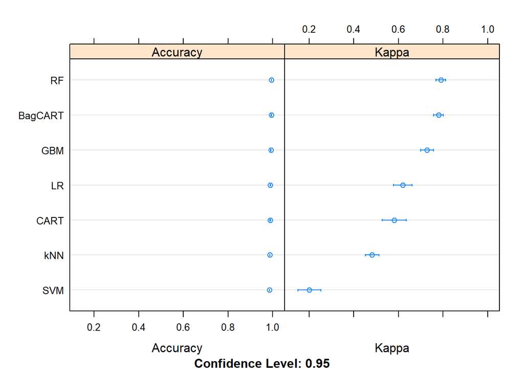

```r
dotplot(results)
```

```r
cat('The average accuracy from all models is:',
    mean(c(results$values$`LR~Accuracy`,results$values$`CART~Accuracy`,results$values$`kNN~Accuracy`,results$values$`SVM~Accuracy`,results$values$`BagCART~Accuracy`,results$values$`RF~Accuracy`,results$values$`GBM~Accuracy`)))
```

```
## The average accuracy from all models is: 0.9899595
```

## 5. Improve Accuracy or Results

After we achieve a short list of machine learning algorithms with good level of accuracy, we can leverage ways to improve the accuracy of the models.

### 5.a) Algorithm Tuning

Finally, we will tune the best-performing algorithms from each group further and see whether we can get more accuracy out of them.

```r
# Tuning algorithm #1 - Bagged CART
startTimeModule <- proc.time()
set.seed(seedNum)
fit.final1 <- fit.bagcart
print(fit.final1)
```

```
## Bagged CART
##
## 60000 samples
##   100 predictor
##     2 classes: 'neg', 'pos'
##
## No pre-processing
## Resampling: Cross-Validated (10 fold, repeated 1 times)
## Summary of sample sizes: 54000, 54000, 54000, 54000, 54000, 54000, ...
## Resampling results:
##
##   Accuracy   Kappa
##   0.9934667  0.7797735
```

```r
proc.time()-startTimeModule
```

```
##    user  system elapsed
##    0.01    0.00    0.02
```

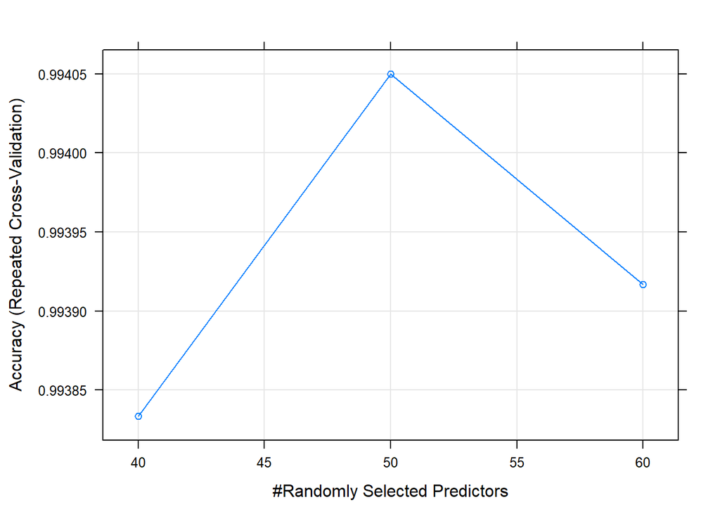

```r
# Tuning algorithm #2 - Random Forest
startTimeModule <- proc.time()
set.seed(seedNum)
grid <- expand.grid(mtry = c(40,50,60))
fit.final2 <- train(targetVar~., data=xy_train, method="rf", metric=metricTarget, tuneGrid=grid, trControl=control)
plot(fit.final2)
```

```r
print(fit.final2)
```

```
## Random Forest
##
## 60000 samples
##   100 predictor
##     2 classes: 'neg', 'pos'
##
## No pre-processing
## Resampling: Cross-Validated (10 fold, repeated 1 times)
## Summary of sample sizes: 54000, 54000, 54000, 54000, 54000, 54000, ...
## Resampling results across tuning parameters:
##
##   mtry  Accuracy   Kappa
##   40    0.9938333  0.7898551
##   50    0.9940500  0.7978243
##   60    0.9939167  0.7931773
##
## Accuracy was used to select the optimal model using the largest value.
## The final value used for the model was mtry = 50.
```

```r
proc.time()-startTimeModule
```

```
##     user   system  elapsed
## 52386.21    82.27 52478.33
```

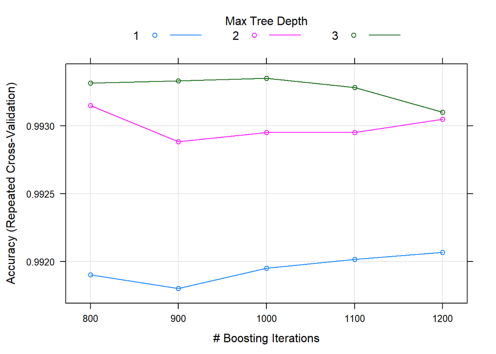

```r
# Tuning algorithm #3 - Stochastic Gradient Boosting
startTimeModule <- proc.time()
set.seed(seedNum)
grid <- expand.grid(.n.trees=c(800,900,1000,1100,1200), .shrinkage=0.1, .interaction.depth=c(1,2,3), .n.minobsinnode=10)
fit.final3 <- train(targetVar~., data=xy_train, method="gbm", metric=metricTarget, tuneGrid=grid, trControl=control, verbose=F)
plot(fit.final3)
```

```r
print(fit.final3)
```

```
## Stochastic Gradient Boosting
##
## 60000 samples
##   100 predictor
##     2 classes: 'neg', 'pos'
##
## No pre-processing
## Resampling: Cross-Validated (10 fold, repeated 1 times)
## Summary of sample sizes: 54000, 54000, 54000, 54000, 54000, 54000, ...
## Resampling results across tuning parameters:
##
##   interaction.depth  n.trees  Accuracy   Kappa
##   1                   800     0.9919000  0.7233094
##   1                   900     0.9918000  0.7207494
##   1                  1000     0.9919500  0.7261918
##   1                  1100     0.9920167  0.7283951
##   1                  1200     0.9920667  0.7316263
##   2                   800     0.9931500  0.7698268
##   2                   900     0.9928833  0.7634214
##   2                  1000     0.9929500  0.7663907
##   2                  1100     0.9929500  0.7668192
##   2                  1200     0.9930500  0.7699644
##   3                   800     0.9933167  0.7799524
##   3                   900     0.9933333  0.7806220
##   3                  1000     0.9933500  0.7819623
##   3                  1100     0.9932833  0.7796648
##   3                  1200     0.9931000  0.7757534
##
## Tuning parameter 'shrinkage' was held constant at a value of 0.1
##
## Tuning parameter 'n.minobsinnode' was held constant at a value of 10
## Accuracy was used to select the optimal model using the largest value.
## The final values used for the model were n.trees = 1000,
##  interaction.depth = 3, shrinkage = 0.1 and n.minobsinnode = 10.
```

```r
proc.time()-startTimeModule
```

```
##    user  system elapsed
## 6694.20    5.75 6700.83
```

### 5.d) Compare Algorithms After Tuning

```r
results <- resamples(list(BagCART=fit.final1, RF=fit.final2, GBM=fit.final3))
summary(results)
```

```
##
## Call:
## summary.resamples(object = results)
##
## Models: BagCART, RF, GBM
## Number of resamples: 10
##
## Accuracy
##              Min.   1st Qu.    Median      Mean   3rd Qu.      Max. NA's
## BagCART 0.9918333 0.9930833 0.9934167 0.9934667 0.9939583 0.9946667    0
## RF      0.9925000 0.9933333 0.9940833 0.9940500 0.9949167 0.9955000    0
## GBM     0.9916667 0.9928750 0.9931667 0.9933500 0.9942500 0.9950000    0
##
## Kappa
##              Min.   1st Qu.    Median      Mean   3rd Qu.      Max. NA's
## BagCART 0.7190904 0.7647205 0.7811627 0.7797735 0.7984699 0.8226124    0
## RF      0.7331488 0.7667222 0.7989983 0.7978243 0.8303385 0.8548647    0
## GBM     0.7269749 0.7581173 0.7815950 0.7819623 0.8155080 0.8395722    0
```

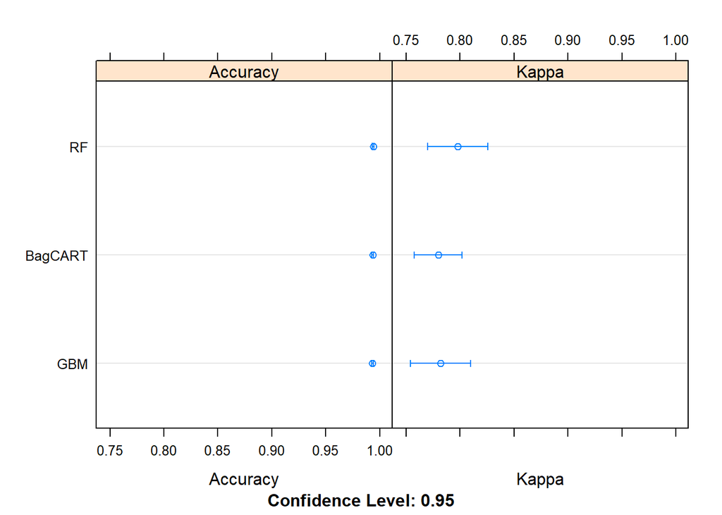

```r
dotplot(results)
```

## 6. Finalize Model and Present Results

Once we have narrow down to a model that we believe can make accurate predictions on unseen data, we are ready to finalize it. Finalizing a model may involve sub-tasks such as:

- Using an optimal model tuned to make predictions on unseen data.
- Creating a standalone model using the tuned parameters
- Saving an optimal model to file for later use.

### 6.a) Predictions on validation dataset

```r
predictions <- predict(fit.final2, newdata=xy_test)
confusionMatrix(predictions, xy_test$targetVar)
```

```
## Confusion Matrix and Statistics
##
##           Reference
## Prediction   neg   pos
##        neg 15606   110
##        pos    19   265
##
##                Accuracy : 0.9919
##                  95% CI : (0.9904, 0.9933)
##     No Information Rate : 0.9766
##     P-Value [Acc > NIR] : < 2.2e-16
##
##                   Kappa : 0.8002
##  Mcnemar's Test P-Value : 2.299e-15
##
##             Sensitivity : 0.9988
##             Specificity : 0.7067
##          Pos Pred Value : 0.9930
##          Neg Pred Value : 0.9331
##              Prevalence : 0.9766
##          Detection Rate : 0.9754
##    Detection Prevalence : 0.9822
##       Balanced Accuracy : 0.8527
##
##        'Positive' Class : neg
##
```

### 6.b) Create standalone model on entire training dataset

```r
startTimeModule <- proc.time()
library(randomForest)
set.seed(seedNum)
finalModel <- randomForest(targetVar~., data=xy_train, mtry=50)
summary(finalModel)
```

```
##                 Length Class  Mode
## call                 4 -none- call
## type                 1 -none- character
## predicted        60000 factor numeric
## err.rate          1500 -none- numeric
## confusion            6 -none- numeric
## votes           120000 matrix numeric
## oob.times        60000 -none- numeric
## classes              2 -none- character
## importance         100 -none- numeric
## importanceSD         0 -none- NULL
## localImportance      0 -none- NULL
## proximity            0 -none- NULL
## ntree                1 -none- numeric
## mtry                 1 -none- numeric
## forest              14 -none- list
## y                60000 factor numeric
## test                 0 -none- NULL
## inbag                0 -none- NULL
## terms                3 terms  call
```

```r
proc.time()-startTimeModule
```

```
##    user  system elapsed
## 2044.67    2.28 2047.29
```

### 6.c) Save model for later use

```r
#saveRDS(finalModel, "./finalModel_MultiClass.rds")
```

```r
proc.time()-startTimeScript
```

```
##     user   system  elapsed
## 144206.1    553.6 144797.4
```